# Capstone 454

Tina Chen, Kyle Suelflow, Samina Stack

12 April, 2024

## Research goals

- What methodology are you exploring?
  - CAR (ICAR) (special case of the Leroux model)
  - BYM (further exploration if we have time)
- What is the motivation / goal behind this methodology? When is it useful?
  - We want to explore how correlated data (Specifically spatial data) and bayesian statistics are connected.
  - This dataset aggregates data in 1 degree latitude by 1 degree longitude cells, as this is the geographic unit for which information such as population data is very complete. It also introduces the measure gross cell product, demonstrating an aggregation measure for economic activity that does not rely on political boundaries.

## Resources

- What resources (eg: books, blogs, articles) are you using to get started?
  - Data resources: SEDAC NASA EOSDIS geographically gridded economic data (our dataset)
  - Class Notes from Correlated Data https://bcheggeseth.github.io/CorrelatedData/areal-data.html
  - Walk through an example hierarchical ICAR model, using both notation and R code. https://atlas.cancer.org.au/developing-a-cancer-atlas/Chapter_4.html
- How do you plan to implement this methodology in R? For example, what packages might be useful? If none exist, what’s your implementation plan?
  - Method r package: Intrinsic Conditional Auto-Regressive (ICAR) models. https://mc-stan.org/users/documentation/case-studies/icar_stan.html

## Methodology background

#### About Areal Data and neightborhood structure

Areal data differs from point data, which consists of measurements from a known set of geo-spatial points. The boundary of areas can be considered polygons determined by a closed sequence of ordered coordinates connected by straight line segments.

For a set of $N$ areal units, the relationship between areal units is described by an $n \times n$ adjacency matrix $W$. The entries indicate whether two regions $n_i$ and $n_j$ are neighbors, with a value of 1 signifying adjacency and 0 indicating non-adjacency. It’s worth noting that in models like Conditional Autoregressive (CAR) models, the neighbor relationship is symmetric, but a region is not considered its own neighbor ($W_{ii} = 0$).

- I see some inconsistency notations (adjacency matrix $A$ and weighted adjacency matrix $W$) used in the r package; I will check it later.

#### Model: Conditional Autoregressive (CAR) Models

$\phi$, an n-length vector $\phi = (\phi_1, ..., \phi_n)^T$, is the spatial random variables that can represent spatial interactions between $n_i$ and $n_j$.

In the full conditional distribution, each $\phi_i$ is conditional on the sum of the weighted values of its neighbors $(w_{ij} \phi_j)$ and has unknown variance.

$$\begin{split}
\phi_i | \phi_j ,j \neq i,
&\sim N (\sum\limits_{j=1}^n w_{ij} \phi_j, \sigma^2)\\
\phi &\sim N(0, Q^{-1})\\
Q &= [D_{\tau}(I - \alpha B)]
\end{split}$$

Where $W$ is the $n \times n$ adjacency matrix where entries $\{i,i\}$ are zero and the off-diagonal elements are 1 if regions $i$ and $j$ are neighbors and 0.

$D$ is the $n \times n$ diagonal matrix where entries $\{i,i\}$ are the number of neighbors of region $i$ and the off-diagonal entries are 0.

$D_{\tau} = \tau D$

$\alpha$ controls the amount of spatial correlation; $\alpha = 0$ implies spatial independence and $\alpha = 1$ implies complete spatial correlation.

$B$ is the scaled adjacency matrix $D^{-1}W$

$I$ is an $n \times n$ identity matrix

#### Assumption

An Intrinsic Conditional Auto-Regressive (ICAR) model is a CAR model where $\alpha=1$ , that is, it assumes complete spatial correlation between regions. (This assumption is problematic). The joint distribution of the ICAR model is derived from the joint distribution for the CAR model as follows:

$$\phi \sim N(0, [\tau(D-W)]^{-1})\\$$
The resulting matrix $[\tau(D-W)]$ is singular, thus the ICAR variate $\phi$ is an improper prior distribution. But it still can be used as a prior part of a hierarchical model.

- since $D_\tau = \tau D$ and $B = D^{-1}W$, the expression $[D_{\tau}(I -\alpha B)]$ simplifies to $[\tau(D-\alpha W)]$
- since $\alpha = 1$, it is omitted.

### Data

#### Data codebook

```r
code_book <- read_excel("Gecon40_post_final.xls", sheet = "definitions")

code_book[c(2,3,4,5,7,8,9,13,14,16,20,25,29,30,34,35,41,44,46),]
```

[output not shown]

#### Data summaries

```r
data_demo <- read_excel("Gecon40_post_final.xls")
dim(data_demo)
```

```
## [1] 27445    47
```

```r
names(data_demo) # need code book
```

```
##  [1] "AREA"             "COUNTRY"          "D1"               "D2"
##  [5] "D3"               "D4"               "DIS_LAKE"         "DIS_MAJOR_RIVER"
##  [9] "DIS_OCEAN"        "DIS_RIVER"        "ELEV_SRTM"        "ELEV_SRTM_PRED"
## [13] "LAT"              "LONGITUDE"        "LONG_NAME"        "MATTVEG"
## [17] "MER1990_40"       "MER1995_40"       "MER2000_40"       "MER2005_40"
## [21] "NEWCOUNTRYID"     "POPGPW_1990_40"   "POPGPW_1995_40"   "POPGPW_2000_40"
## [25] "POPGPW_2005_40"   "PPP1990_40"       "PPP1995_40"       "PPP2000_40"
## [29] "PPP2005_40"       "PREC_NEW"         "PRECMAX"          "PRECMIN"
## [33] "PRECSD"           "PRECAVNEW80_08"   "PRECSDNEW80_08"   "QUALITY"
## [37] "RIG_xi0710"       "ROUGH"            "SOIL_UNIT"        "TEMP_NEW"
## [41] "TEMPAV_8008"      "TEMPMAX"          "TEMPMIN"          "TEMPSD"
## [45] "TEMPSD80_08"      "QUALITY_REVISION" "DATE OF LAST"
```

```r
head(data_demo)
```

```
## # A tibble: 6 × 47
##    AREA COUNTRY              D1      D2      D3      D4 DIS_LAKE DIS_MAJOR_RIVER
##   <dbl> <chr>             <dbl>   <dbl>   <dbl>   <dbl>    <dbl>           <dbl>
## 1   0   Bosnia&Herzego…   0       0       0       0          NA              NA
## 2  10.5 Brazil          253.    182.    169.    157.     156602          181754.
## 3  33.6 Brazil          640.    109.    109.    109.     580072.         109199.
## 4  12.2 Brazil          566.    566.    523.    523.     630610.         683544.
## 5  36.5 Brazil          604.    604.    548.    548.     615036.         671246.
## 6   0   Brazil            0.287   0.287   0.287   0.287  522919.        1508678
## # ℹ 39 more variables: DIS_OCEAN <dbl>, DIS_RIVER <dbl>, ELEV_SRTM <dbl>,
## #   ELEV_SRTM_PRED <dbl>, LAT <dbl>, LONGITUDE <dbl>, LONG_NAME <chr>,
## #   MATTVEG <dbl>, MER1990_40 <dbl>, MER1995_40 <dbl>, MER2000_40 <dbl>,
## #   MER2005_40 <dbl>, NEWCOUNTRYID <dbl>, POPGPW_1990_40 <dbl>,
## #   POPGPW_1995_40 <dbl>, POPGPW_2000_40 <dbl>, POPGPW_2005_40 <dbl>,
## #   PPP1990_40 <dbl>, PPP1995_40 <dbl>, PPP2000_40 <dbl>, PPP2005_40 <dbl>,
## #   PREC_NEW <dbl>, PRECMAX <dbl>, PRECMIN <dbl>, PRECSD <dbl>, …
```

```r
# number of countries in the dataset
data_demo %>% count(COUNTRY) %>% nrow()
```

```
## [1] 246
```

#### Visualization

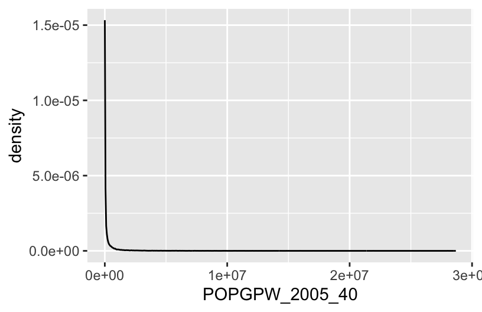

```r
data_demo %>% filter( POPGPW_2005_40 !=0) %>%
ggplot(aes(x=POPGPW_2005_40))+
  geom_density()
```

- Note: POPGPW_2005_40 is Grid cell population, 2005. This is a count variables, need to be logged to make sure data can live from 0 to infinity.

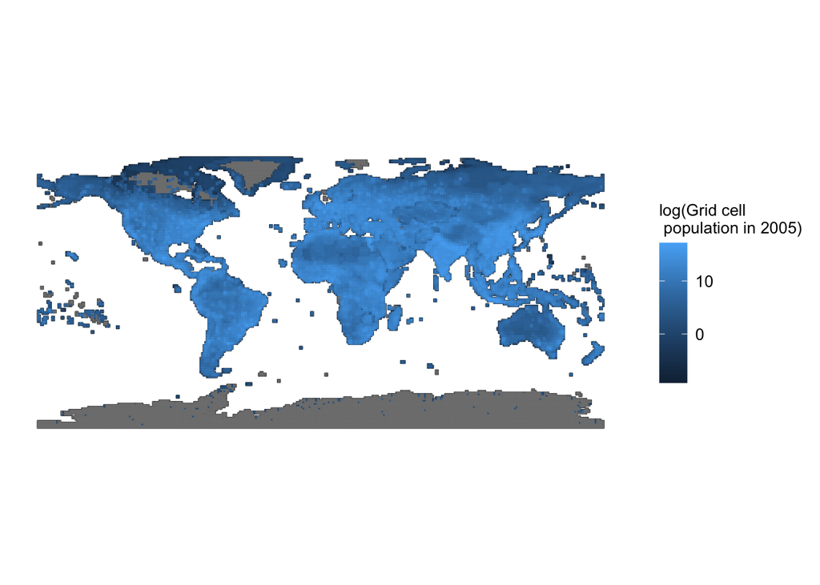

```r
# world map

points_sf <- data_demo %>%
  st_as_sf(coords = c("LONGITUDE", "LAT"), crs = 4326)

# Expand each point to cover a 1x1 degree grid
expanded_grid <- st_make_grid(points_sf, cellsize = c(1, 1))

index <- which(lengths(st_intersects(expanded_grid, points_sf)) > 0)

# Filter out only the intersecting grid cells
fishnet <- expanded_grid[index]

# Convert the grid cells to sf, create unique IDs, and join with points
joined_data <- fishnet %>%
  st_as_sf() %>%
  mutate(grid_id = row_number()) %>%
  st_join(points_sf)


ggplot() +
  geom_sf(data = fishnet, fill = NA, color = "black") +
  geom_sf(data = joined_data,
          aes(fill = log(POPGPW_2005_40)), color = NA) +
  theme_classic()+
  theme(legend.title = element_text(size = 10),
               legend.text = element_text(size = 10))+
  labs(fill = "log(Grid cell\n population in 2005)")
```

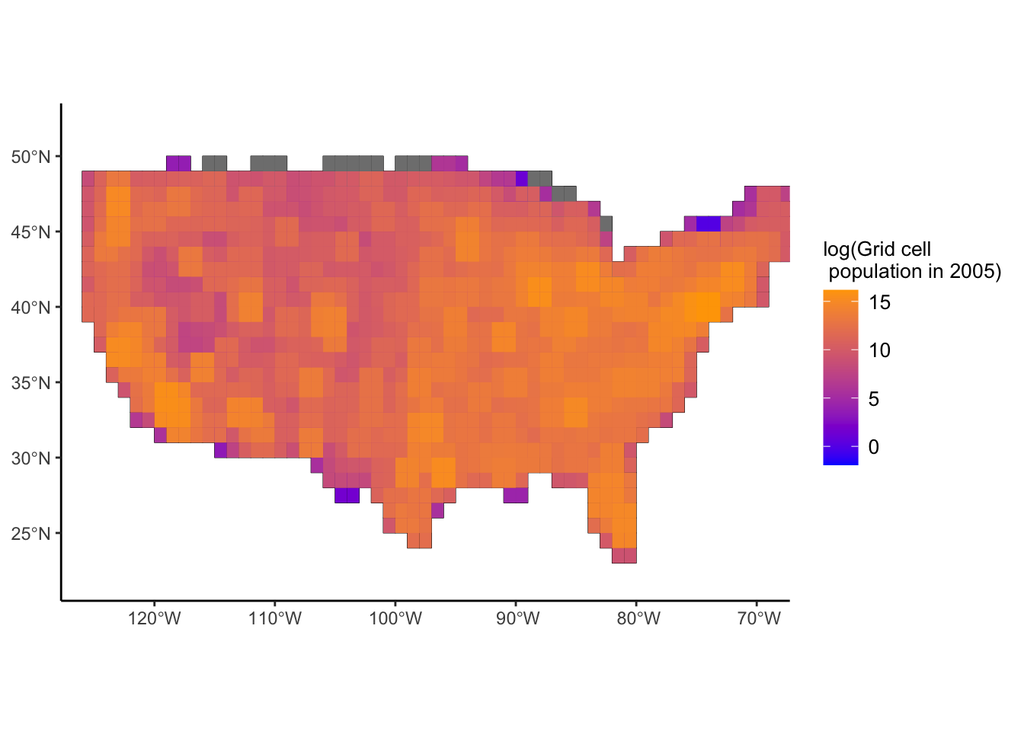

```r
# only US focus
points_sf <- data_demo %>% filter(COUNTRY == "United States") %>%
  st_as_sf(coords = c("LONGITUDE", "LAT"), crs = 4326)

# Expand each point to cover a 1x1 degree grid
expanded_grid <- st_make_grid(points_sf, cellsize = c(1, 1))

index <- which(lengths(st_intersects(expanded_grid, points_sf)) > 0)

# Filter out only the intersecting grid cells
fishnet <- expanded_grid[index]

# Convert the grid cells to sf, create unique IDs, and join with points
joined_data <- fishnet %>%
  st_as_sf() %>%
  mutate(grid_id = row_number()) %>%
  st_join(points_sf)


ggplot() +
  geom_sf(data = fishnet, fill = NA, color = "black") +
  geom_sf(data = joined_data,
          aes(fill = log(POPGPW_2005_40)), color = NA) +
  theme_classic()+
  theme(legend.title = element_text(size = 10),
               legend.text = element_text(size = 10))+
  labs(fill = "log(Grid cell\n population in 2005)")+
  coord_sf(xlim = c(-125, -70),ylim = c(22, 52))+
scale_fill_gradient(low = "blue", high = "orange")
```

- to do: tweak the parameters for prior (hierarchical model)